# restingstate

2023-05-03

correlations between the three pairs–it looks like pair 1 is best with r = .71

```r
cor_target_pair1 <- cor(data$diff_target, data$diff_pair1, method = "pearson")
cor_target_pair3 <- cor(data$diff_target, data$diff_pair3, method = "pearson")
cor_target_pair4 <- cor(data$diff_target, data$diff_pair4, method = "pearson")

cor_target_pair1
```

```
## [1] -0.711123
```

```r
cor_target_pair3
```

```
## [1] 0.194937
```

```r
cor_target_pair4
```

```
## [1] -0.03491835
```

then just looking at pair 1, we can run a simple linear regression–we see that this is signficant with p = 0.0141

```r
reg_target_pair1 <- lm(diff_target ~ diff_pair1, data = data)
summary(reg_target_pair1)
```

```
##
## Call:
## lm(formula = diff_target ~ diff_pair1, data = data)
##
## Residuals:
##      Min       1Q   Median       3Q      Max
## -1.97120 -0.63733 -0.05348  0.84325  1.45546
##
## Coefficients:
##             Estimate Std. Error t value Pr(>|t|)
## (Intercept)   1.7390     0.8675   2.005   0.0760 .
## diff_pair1   -0.2176     0.0717  -3.034   0.0141 *
## ---
## Signif. codes:  0 '***' 0.001 '**' 0.01 '*' 0.05 '.' 0.1 ' ' 1
##
## Residual standard error: 1.189 on 9 degrees of freedom
## Multiple R-squared:  0.5057, Adjusted R-squared:  0.4508
## F-statistic: 9.207 on 1 and 9 DF,  p-value: 0.01415
```

controlling for date, phobias and dosage group

```r
reg_target_pair1_controlled.1 <- lm(diff_target ~ diff_pair1 + diff_date + num..phobias + dosage, data = data)
summary(reg_target_pair1_controlled.1)
```

```
##
## Call:
## lm(formula = diff_target ~ diff_pair1 + diff_date + num..phobias +
##     dosage, data = data)
##
## Residuals:
##     Min      1Q  Median      3Q     Max
## -1.7143 -0.3857  0.3440  0.6362  0.7337
##
## Coefficients:
##               Estimate Std. Error t value Pr(>|t|)
## (Intercept)  -0.921331   1.833899  -0.502   0.6333
## diff_pair1   -0.238442   0.076736  -3.107   0.0209 *
## diff_date     0.001808   0.005114   0.353   0.7358
## num..phobias  1.043990   0.545683   1.913   0.1042
## dosage        0.036137   0.282914   0.128   0.9025
## ---
## Signif. codes:  0 '***' 0.001 '**' 0.01 '*' 0.05 '.' 0.1 ' ' 1
##
## Residual standard error: 1.143 on 6 degrees of freedom
## Multiple R-squared:  0.6955, Adjusted R-squared:  0.4924
## F-statistic: 3.426 on 4 and 6 DF,  p-value: 0.08717
```

```r
reg_control_pair1 <- lm(diff_control ~ diff_pair1 + diff_date + num..phobias + dosage, data = data)
summary(reg_control_pair1)
```

```
##
## Call:
## lm(formula = diff_control ~ diff_pair1 + diff_date + num..phobias +
##     dosage, data = data)
##
## Residuals:
##      Min       1Q   Median       3Q      Max
## -1.39289 -0.77203 -0.05887  0.74811  1.76245
##
## Coefficients:
##               Estimate Std. Error t value Pr(>|t|)
## (Intercept)   0.739030   2.023682   0.365    0.727
## diff_pair1   -0.024549   0.084677  -0.290    0.782
## diff_date     0.005415   0.005643   0.960    0.374
## num..phobias  0.109487   0.602153   0.182    0.862
## dosage       -0.473763   0.312192  -1.518    0.180
##
## Residual standard error: 1.261 on 6 degrees of freedom
## Multiple R-squared:  0.3863, Adjusted R-squared:  -0.02286
## F-statistic: 0.9441 on 4 and 6 DF,  p-value: 0.499
```

```r
reg_target_pair1_controlled.2 <- lm(diff_target ~ diff_pair1 + diff_control + diff_date + num..phobias + dosage, data = data)
summary(reg_target_pair1_controlled.2)
```

```
##
## Call:
## lm(formula = diff_target ~ diff_pair1 + diff_control + diff_date +
##     num..phobias + dosage, data = data)
##
## Residuals:
##         1         2         3         4         5         6         7         8
##  1.005710 -0.564963  0.106366  0.079947  0.006515 -1.560680  0.592789  0.899942
##         9        10        11
## -1.229072  0.293423  0.370024
##
## Coefficients:
##                Estimate Std. Error t value Pr(>|t|)
## (Intercept)  -1.179e+00  1.875e+00  -0.629   0.5572
## diff_pair1   -2.299e-01  7.814e-02  -2.942   0.0322 *
## diff_control  3.484e-01  3.741e-01   0.931   0.3945
## diff_date    -7.872e-05  5.554e-03  -0.014   0.9892
## num..phobias  1.006e+00  5.533e-01   1.818   0.1288
## dosage        2.012e-01  3.366e-01   0.598   0.5760
## ---
## Signif. codes:  0 '***' 0.001 '**' 0.01 '*' 0.05 '.' 0.1 ' ' 1
##
## Residual standard error: 1.156 on 5 degrees of freedom
## Multiple R-squared:  0.7405, Adjusted R-squared:  0.4809
## F-statistic: 2.853 on 5 and 5 DF,  p-value: 0.1373
```

how about switching the connectivity and the amygdala around and include control as interaction?

```r
flipped <- lm(diff_pair1 ~ diff_target*diff_control + diff_date + num..phobias + dosage, data = data)
summary(flipped)
```

```
##
## Call:
## lm(formula = diff_pair1 ~ diff_target * diff_control + diff_date +
##     num..phobias + dosage, data = data)
##
## Residuals:
##       1       2       3       4       5       6       7       8       9      10
##  1.9339 -2.2274  1.6870 -0.6187 -0.3439 -5.6515 -1.3144  1.7125 -0.6101  3.9577
##      11
##  1.4750
##
## Coefficients:
##                           Estimate Std. Error t value Pr(>|t|)
## (Intercept)              -3.764711   8.003725  -0.470   0.6626
## diff_target              -3.390690   1.192847  -2.843   0.0467 *
## diff_control              0.058839   1.595968   0.037   0.9724
## diff_date                -0.002866   0.020188  -0.142   0.8940
## num..phobias              3.978017   2.257948   1.762   0.1529
## dosage                    0.942121   1.250374   0.753   0.4931
## diff_target:diff_control -0.660031   0.741459  -0.890   0.4237
## ---
## Signif. codes:  0 '***' 0.001 '**' 0.01 '*' 0.05 '.' 0.1 ' ' 1
##
## Residual standard error: 4.088 on 4 degrees of freedom
## Multiple R-squared:  0.7568, Adjusted R-squared:  0.392
## F-statistic: 2.075 on 6 and 4 DF,  p-value: 0.2503
```

what if we try to run the same analysis but for the control?

```r
reg_control_pair1_controlled <- lm(diff_control ~ diff_pair1 + diff_date + num..phobias + dosage, data = data)
summary(reg_control_pair1_controlled)
```

```
##
## Call:
## lm(formula = diff_control ~ diff_pair1 + diff_date + num..phobias +
##     dosage, data = data)
##
## Residuals:
##      Min       1Q   Median       3Q      Max
## -1.39289 -0.77203 -0.05887  0.74811  1.76245
##
## Coefficients:
##               Estimate Std. Error t value Pr(>|t|)
## (Intercept)   0.739030   2.023682   0.365    0.727
## diff_pair1   -0.024549   0.084677  -0.290    0.782
## diff_date     0.005415   0.005643   0.960    0.374
## num..phobias  0.109487   0.602153   0.182    0.862
## dosage       -0.473763   0.312192  -1.518    0.180
##
## Residual standard error: 1.261 on 6 degrees of freedom
## Multiple R-squared:  0.3863, Adjusted R-squared:  -0.02286
## F-statistic: 0.9441 on 4 and 6 DF,  p-value: 0.499
```

no significant results when running for control!!

doing a hierarchical regression in order to find the R2 for just the predictor

```r
intercept = lm(diff_target ~ 1, data = data)
model1 = lm(diff_target ~ num..phobias, data = data)
model2 = lm(diff_target ~ num..phobias + dosage, data = data)
model3 = lm(diff_target ~ num..phobias + dosage + diff_date, data = data)
model4 = lm(diff_target ~ num..phobias + dosage + diff_date + diff_pair1, data = data)
anova(intercept, model1, model2, model3, model4)
```

```
## Analysis of Variance Table
##
## Model 1: diff_target ~ 1
## Model 2: diff_target ~ num..phobias
## Model 3: diff_target ~ num..phobias + dosage
## Model 4: diff_target ~ num..phobias + dosage + diff_date
## Model 5: diff_target ~ num..phobias + dosage + diff_date + diff_pair1
##   Res.Df     RSS Df Sum of Sq      F  Pr(>F)
## 1     10 25.7354
## 2      9 24.0341  1    1.7014 1.3025 0.29725
## 3      8 23.9830  1    0.0510 0.0391 0.84987
## 4      7 20.4493  1    3.5337 2.7053 0.15112
## 5      6  7.8373  1   12.6120 9.6553 0.02092 *
## ---
## Signif. codes:  0 '***' 0.001 '**' 0.01 '*' 0.05 '.' 0.1 ' ' 1
```

to find the R2, we do:

```r
#SS model 3 - model 4
R2 <- 20.4493 - 7.8373

#divide by total SS of model
R2 <- R2 / 25.7354

R2
```

```
## [1] 0.4900643
```

doing r2 for the control animal

```r
intercept = lm(diff_control ~ 1, data = data)
model1 = lm(diff_control ~ num..phobias, data = data)
model2 = lm(diff_control ~ num..phobias + dosage, data = data)
model3 = lm(diff_control ~ num..phobias + dosage + diff_date, data = data)
model4 = lm(diff_control ~ num..phobias + dosage + diff_date + diff_pair1, data = data)
anova(intercept, model1, model2, model3, model4)
```

```
## Analysis of Variance Table
##
## Model 1: diff_control ~ 1
## Model 2: diff_control ~ num..phobias
## Model 3: diff_control ~ num..phobias + dosage
## Model 4: diff_control ~ num..phobias + dosage + diff_date
## Model 5: diff_control ~ num..phobias + dosage + diff_date + diff_pair1
##   Res.Df     RSS Df Sum of Sq      F Pr(>F)
## 1     10 15.5502
## 2      9 15.4638  1    0.0864 0.0543 0.8235
## 3      8 11.7939  1    3.6699 2.3073 0.1796
## 4      7  9.6771  1    2.1169 1.3309 0.2925
## 5      6  9.5434  1    0.1337 0.0840 0.7816
```

to find R2,

```r
R2_2 <- 9.6771 - 9.5434
R2_2 <- R2_2 / 15.5502

R2_2
```

```
## [1] 0.00859796
```

michelle wanted to control for time between decoder/post, so here–is still significant with p = .0323

```r
reg_target_pair1_controlled.1 <- lm(diff_target ~ diff_pair1 + diff_date, data = data)
summary(reg_target_pair1_controlled.1)
```

```
##
## Call:
## lm(formula = diff_target ~ diff_pair1 + diff_date, data = data)
##
## Residuals:
##      Min       1Q   Median       3Q      Max
## -1.93749 -0.68551 -0.03439  0.86765  1.42854
##
## Coefficients:
##              Estimate Std. Error t value Pr(>|t|)
## (Intercept)  1.674211   1.148099   1.458   0.1829
## diff_pair1  -0.214451   0.082922  -2.586   0.0323 *
## diff_date    0.000525   0.005566   0.094   0.9272
## ---
## Signif. codes:  0 '***' 0.001 '**' 0.01 '*' 0.05 '.' 0.1 ' ' 1
##
## Residual standard error: 1.26 on 8 degrees of freedom
## Multiple R-squared:  0.5062, Adjusted R-squared:  0.3828
## F-statistic: 4.101 on 2 and 8 DF,  p-value: 0.05944
```

now adding to the model by controlling for the control difference in activation–becomes only marginally significant with p = .0509

do we want to keep this model with these controls and try to do something else with it?

```r
reg_target_pair1_controlled.2 <- lm(diff_target ~ diff_pair1 + diff_date + diff_control, data = data)
summary(reg_target_pair1_controlled.2)
```

```
##
## Call:
## lm(formula = diff_target ~ diff_pair1 + diff_date + diff_control,
##     data = data)
##
## Residuals:
##     Min      1Q  Median      3Q     Max
## -2.1057 -0.7547  0.3698  0.7886  1.3384
##
## Coefficients:
##                Estimate Std. Error t value Pr(>|t|)
## (Intercept)   1.7845838  1.1986877   1.489   0.1802
## diff_pair1   -0.2046327  0.0869764  -2.353   0.0509 .
## diff_date    -0.0006126  0.0059912  -0.102   0.9214
## diff_control  0.2466823  0.3586970   0.688   0.5138
## ---
## Signif. codes:  0 '***' 0.001 '**' 0.01 '*' 0.05 '.' 0.1 ' ' 1
##
## Residual standard error: 1.304 on 7 degrees of freedom
## Multiple R-squared:  0.5375, Adjusted R-squared:  0.3393
## F-statistic: 2.712 on 3 and 7 DF,  p-value: 0.1251
```

it becomes significant again if we control for number of phobias but do we have justification for this? may be promising?

```r
reg_target_pair1_controlled.3 <- lm(diff_target ~ diff_pair1 + diff_date + diff_control + num..phobias, data = data)
summary(reg_target_pair1_controlled.3)
```

```
##
## Call:
## lm(formula = diff_target ~ diff_pair1 + diff_date + diff_control +
##     num..phobias, data = data)
##
## Residuals:
##     Min      1Q  Median      3Q     Max
## -1.5368 -0.3940  0.0914  0.6672  1.0115
##
## Coefficients:
##                Estimate Std. Error t value Pr(>|t|)
## (Intercept)  -0.6937228  1.5972806  -0.434   0.6792
## diff_pair1   -0.2277905  0.0737638  -3.088   0.0214 *
## diff_date     0.0007874  0.0050666   0.155   0.8816
## diff_control  0.2306004  0.3005247   0.767   0.4720
## num..phobias  1.0380872  0.5203830   1.995   0.0931 .
## ---
## Signif. codes:  0 '***' 0.001 '**' 0.01 '*' 0.05 '.' 0.1 ' ' 1
##
## Residual standard error: 1.092 on 6 degrees of freedom
## Multiple R-squared:  0.7219, Adjusted R-squared:  0.5365
## F-statistic: 3.894 on 4 and 6 DF,  p-value: 0.06807
```

i then went and subtracted the raw control scores from the raw pre scores and took those raw scores and subtracted pre from post and reran controlling for time, no significance

```r
reg_target_control_pair1 <- lm(target_control_diff ~ diff_pair1 + diff_date, data = data)
summary(reg_target_control_pair1)
```

```
##
## Call:
## lm(formula = target_control_diff ~ diff_pair1 + diff_date, data = data)
##
## Residuals:
##     Min      1Q  Median      3Q     Max
## -2.6194 -0.8876  0.2174  0.9888  1.7137
##
## Coefficients:
##              Estimate Std. Error t value Pr(>|t|)
## (Intercept)  2.121640   1.418691   1.495    0.173
## diff_pair1  -0.174649   0.102466  -1.704    0.127
## diff_date   -0.004087   0.006877  -0.594    0.569
##
## Residual standard error: 1.557 on 8 degrees of freedom
## Multiple R-squared:  0.267,  Adjusted R-squared:  0.08376
## F-statistic: 1.457 on 2 and 8 DF,  p-value: 0.2887
```

now using induction average as outcome

```r
reg_induction_avg_pair1 <- lm(induction_avg ~ diff_pair1, data = data)
summary(reg_induction_avg_pair1)
```

```
##
## Call:
## lm(formula = induction_avg ~ diff_pair1, data = data)
##
## Residuals:
##    Min     1Q Median     3Q    Max
## -6.966 -4.314  1.957  3.259  7.622
##
## Coefficients:
##             Estimate Std. Error t value Pr(>|t|)
## (Intercept)  50.5874     3.8281  13.215 3.37e-07 ***
## diff_pair1    0.2635     0.3164   0.833    0.427
## ---
## Signif. codes:  0 '***' 0.001 '**' 0.01 '*' 0.05 '.' 0.1 ' ' 1
##
## Residual standard error: 5.247 on 9 degrees of freedom
## Multiple R-squared:  0.07152,    Adjusted R-squared:  -0.03165
## F-statistic: 0.6932 on 1 and 9 DF,  p-value: 0.4266
```

also while controlling for date

```r
reg_induction_avg_pair1_controlled.1 <- lm(induction_avg ~ diff_pair1 + diff_date, data = data)
summary(reg_induction_avg_pair1_controlled.1)
```

```
##
## Call:
## lm(formula = induction_avg ~ diff_pair1 + diff_date, data = data)
##
## Residuals:
##    Min     1Q Median     3Q    Max
## -9.044 -1.231  1.173  2.748  5.884
##
## Coefficients:
##             Estimate Std. Error t value Pr(>|t|)
## (Intercept) 54.58349    4.48670  12.166 1.93e-06 ***
## diff_pair1   0.07080    0.32406   0.218    0.833
## diff_date   -0.03235    0.02175  -1.488    0.175
## ---
## Signif. codes:  0 '***' 0.001 '**' 0.01 '*' 0.05 '.' 0.1 ' ' 1
##
## Residual standard error: 4.925 on 8 degrees of freedom
## Multiple R-squared:  0.2727, Adjusted R-squared:  0.09087
## F-statistic:   1.5 on 2 and 8 DF,  p-value: 0.2798
```

no significance with either models for induction average–what about induction learning (post - pre)? now using induction average as outcome

```r
reg_induction_learning_pair1 <- lm(induction_learning ~ diff_pair1, data = data)
summary(reg_induction_learning_pair1)
```

```
##
## Call:
## lm(formula = induction_learning ~ diff_pair1, data = data)
##
## Residuals:
##    Min     1Q Median     3Q    Max
## -68.62 -27.79   5.46  31.82  50.54
##
## Coefficients:
##             Estimate Std. Error t value Pr(>|t|)
## (Intercept)   37.771     30.220   1.250    0.243
## diff_pair1    -1.940      2.498  -0.777    0.457
##
## Residual standard error: 41.42 on 9 degrees of freedom
## Multiple R-squared:  0.06281,    Adjusted R-squared:  -0.04132
## F-statistic: 0.6032 on 1 and 9 DF,  p-value: 0.4573
```

also while controlling for date–big difference? wondering why, also weird how time is significant as well

```r
reg_induction_learning_pair1_controlled.1 <- lm(induction_learning ~ diff_pair1 + diff_date, data = data)
summary(reg_induction_learning_pair1_controlled.1)
```

```
##
## Call:
## lm(formula = induction_learning ~ diff_pair1 + diff_date, data = data)
##
## Residuals:
##     Min      1Q  Median      3Q     Max
## -25.816 -13.627   3.108  15.043  24.371
##
## Coefficients:
##             Estimate Std. Error t value Pr(>|t|)
## (Intercept) 97.93280   18.42358   5.316 0.000715 ***
## diff_pair1  -4.84062    1.33066  -3.638 0.006610 **
## diff_date   -0.48709    0.08931  -5.454 0.000606 ***
## ---
## Signif. codes:  0 '***' 0.001 '**' 0.01 '*' 0.05 '.' 0.1 ' ' 1
##
## Residual standard error: 20.22 on 8 degrees of freedom
## Multiple R-squared:  0.8014, Adjusted R-squared:  0.7517
## F-statistic: 16.14 on 2 and 8 DF,  p-value: 0.001557
```

induction learning with date, phobias, dosage

```r
reg_induction_learning_pair1_controlled.1 <- lm(induction_learning ~ diff_pair1 + diff_date + num..phobias + dosage, data = data)
summary(reg_induction_learning_pair1_controlled.1)
```

```
##
## Call:
## lm(formula = induction_learning ~ diff_pair1 + diff_date + num..phobias +
##     dosage, data = data)
##
## Residuals:
##     Min      1Q  Median      3Q     Max
## -28.607  -7.554   4.319   7.755  27.421
##
## Coefficients:
##              Estimate Std. Error t value Pr(>|t|)
## (Intercept)  62.66755   32.77220   1.912  0.10439
## diff_pair1   -5.17878    1.37129  -3.777  0.00922 **
## diff_date    -0.47362    0.09139  -5.183  0.00205 **
## num..phobias 12.51508    9.75147   1.283  0.24669
## dosage        1.79207    5.05574   0.354  0.73512
## ---
## Signif. codes:  0 '***' 0.001 '**' 0.01 '*' 0.05 '.' 0.1 ' ' 1
##
## Residual standard error: 20.42 on 6 degrees of freedom
## Multiple R-squared:  0.8481, Adjusted R-squared:  0.7468
## F-statistic: 8.373 on 4 and 6 DF,  p-value: 0.01243
```

scatterplot for induction learning

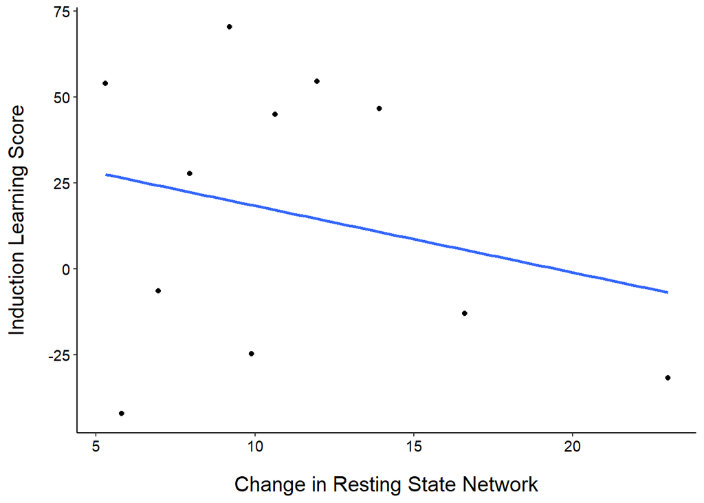

```r
ind_learn_scatter <- ggplot(data, aes(x = diff_pair1, y = induction_learning)) +
  geom_point() +
  geom_smooth(method = lm, se = FALSE) +
  labs(x = "Change in Resting State Network",
       y = "Induction Learning Score") +
  theme_classic() +
  theme(axis.title = element_text(size = 15),
        axis.text = element_text(size = 11, colour = "black"),
        axis.title.y = element_text(margin = margin(t = 0, r = 15, b = 0, l = 0)),
        axis.title.x = element_text(margin = margin(t = 15)))
ind_learn_scatter
```

```r
ggsave("ind_learn_scatter.png", width = 6, height = 4.5, dpi = 600, units = "in")
```

scatterplot with the amygdala changes making the line red instead of blue

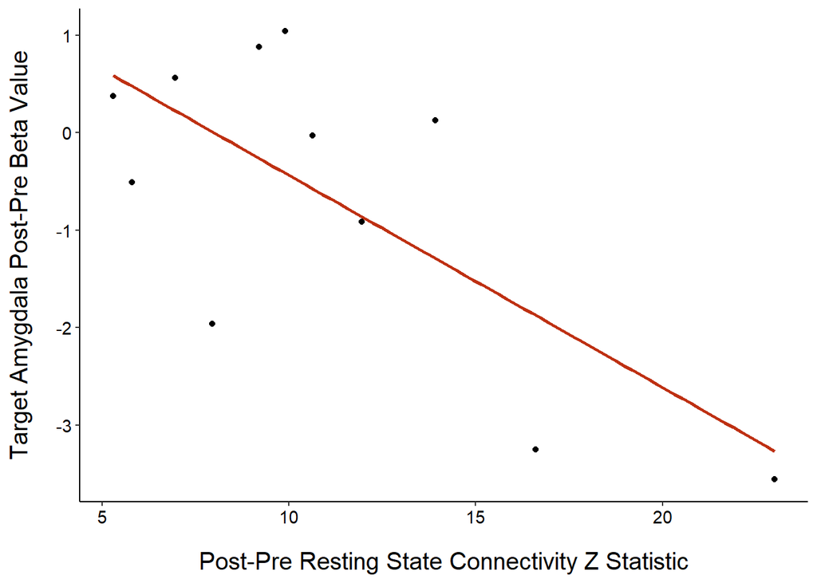

```r
amyg_scatter <- ggplot(data, aes(x = diff_pair1, y = diff_target)) +
  geom_point() +
  stat_smooth(method = lm, se = FALSE, fullrange = TRUE, color = "#BE3011")+
  labs(x = "Post-Pre Resting State Connectivity Z Statistic",
       y = "Target Amygdala Post-Pre Beta Value") +
  theme_classic() +
  theme(axis.title = element_text(size = 15),
        axis.text = element_text(size = 11, colour = "black"),
        axis.title.y = element_text(margin = margin(t = 0, r = 15, b = 0, l = 0)),
        axis.title.x = element_text(margin = margin(t = 15))) #make the numbers on axes larger

amyg_scatter
```

```r
ggsave("target_scatter.png", dpi = 600, width = 6, height = 4.5, units = "in")
```

doing an amygdala scatterplot for the control condition

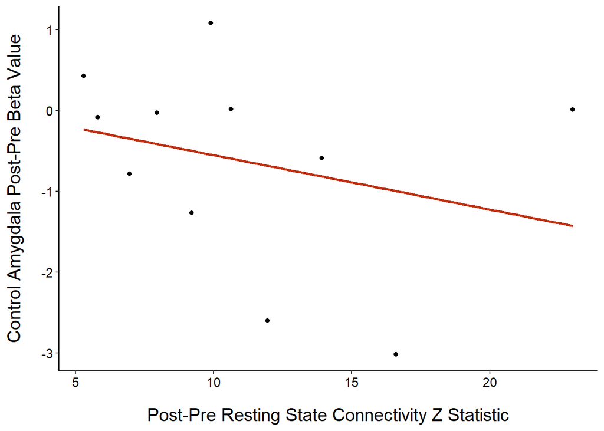

```r
control_scatter <- ggplot(data, aes(x = diff_pair1, y = diff_control)) +
  geom_point() +
  stat_smooth(method = lm, se = FALSE, fullrange = TRUE, color = "#BE3011")+
  labs(x = "Post-Pre Resting State Connectivity Z Statistic",
       y = "Control Amygdala Post-Pre Beta Value") +
  theme_classic() +
  theme(axis.title = element_text(size = 15),
        axis.text = element_text(size = 11, colour = "black"),
        axis.title.y = element_text(margin = margin(t = 0, r = 15, b = 0, l = 0)),
        axis.title.x = element_text(margin = margin(t = 15))) #make the numbers on axes larger
control_scatter
```

```r
ggsave("control_scatter.png", dpi = 600, width = 6, height = 4.5, units = "in")
```

looks like the MORE change in RSN, the WORSE induction learning is and the MORE changes in amygdala–these two findings are a bit in conflict with one another

how does the amygdala reactivity relate to the induction learning?

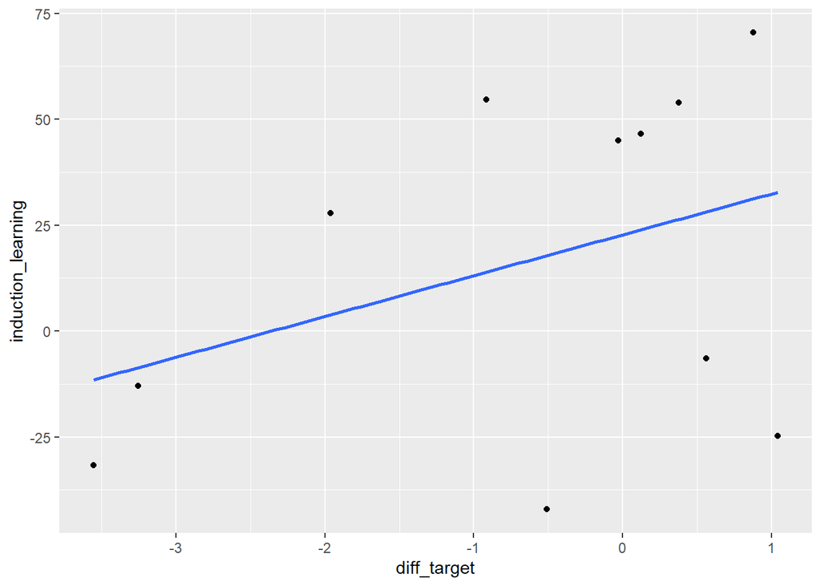

```r
amyg_induct <- ggplot(data, aes(x = diff_target, y = induction_learning)) +
  geom_point() +
  geom_smooth(method = lm, se = FALSE)

amyg_induct
```

it looks like the greater your change in amygdala, the better you are at induction learning–however, the direction that these are in means that the those who experienced increases in amygdala (because post - pre) had better induction learning??

```r
removedData <- data[-c(10),]

reg_target_pair1 <- lm(diff_target ~ diff_pair1, data = removedData)
summary(reg_target_pair1)
```

```
##
## Call:
## lm(formula = diff_target ~ diff_pair1, data = removedData)
##
## Residuals:
##     Min      1Q  Median      3Q     Max
## -1.9389 -0.7007  0.1537  0.9726  1.4241
##
## Coefficients:
##             Estimate Std. Error t value Pr(>|t|)
## (Intercept)   1.4475     1.2028   1.203    0.263
## diff_pair1   -0.1849     0.1157  -1.598    0.149
##
## Residual standard error: 1.25 on 8 degrees of freedom
## Multiple R-squared:  0.242,  Adjusted R-squared:  0.1473
## F-statistic: 2.555 on 1 and 8 DF,  p-value: 0.1486
```

```r
reg_induction_learning_pair1_controlled.1 <- lm(induction_learning ~ diff_pair1 + diff_date + num..phobias + dosage, data = removedData)
summary(reg_induction_learning_pair1_controlled.1)
```

```
##
## Call:
## lm(formula = induction_learning ~ diff_pair1 + diff_date + num..phobias +
##     dosage, data = removedData)
##
## Residuals:
##       1       2       3       4       5       6       7       8       9      11
##  -7.206   8.490  -9.051   5.205 -10.061 -17.530  10.875  31.512 -22.785  10.551
##
## Coefficients:
##              Estimate Std. Error t value Pr(>|t|)
## (Intercept)   59.1670    35.7227   1.656  0.15857
## diff_pair1    -6.6611     3.3029  -2.017  0.09978 .
## diff_date     -0.4876     0.1016  -4.799  0.00489 **
## num..phobias  17.6830    14.6676   1.206  0.28191
## dosage         3.1937     6.0861   0.525  0.62218
## ---
## Signif. codes:  0 '***' 0.001 '**' 0.01 '*' 0.05 '.' 0.1 ' ' 1
##
## Residual standard error: 21.83 on 5 degrees of freedom
## Multiple R-squared:  0.8289, Adjusted R-squared:  0.692
## F-statistic: 6.055 on 4 and 5 DF,  p-value: 0.03721
```

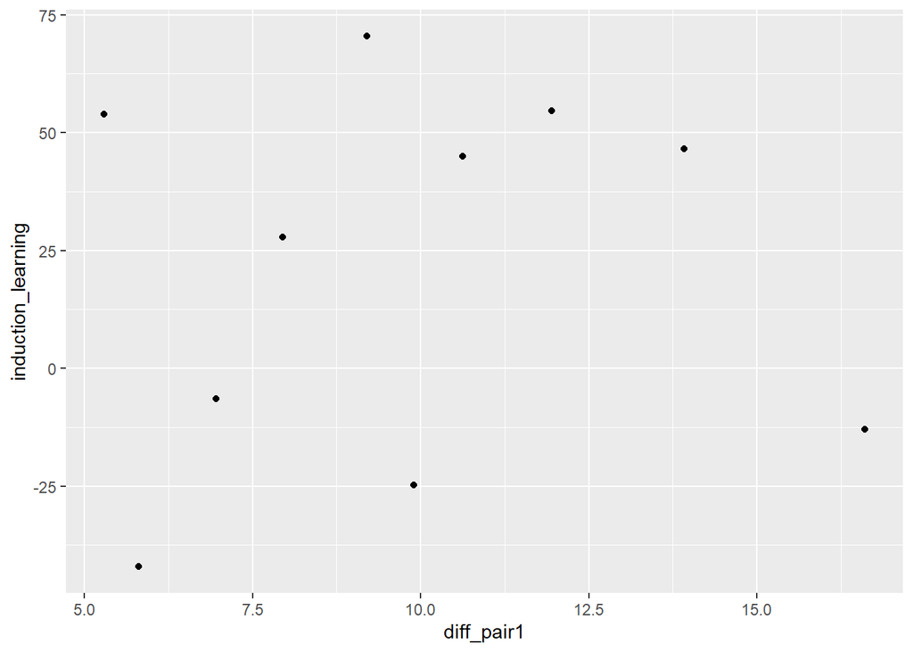

```r
test <- ggplot(removedData, aes(x = diff_pair1, y = induction_learning)) +
  geom_point()
test
```

now to replicate vincent’s analysis

```r
vincent_final_data <- vincent_final_data %>%
  mutate(pair1_diff = pair1_post - pair_1_pre,
         pair2_diff = pair2_post - pair_2_pre,
         amyg_target_diff = Amyg_D_2 - Amyg_D_1,
         amyg_control_diff = Amyg_C_2 - Amyg_C_1)


vincent_reg_pair1 <- lm(amyg_target_diff ~ pair1_diff + amyg_control_diff, data = vincent_final_data)

vincent_reg_pair2 <- lm(amyg_target_diff ~ pair2_diff + amyg_control_diff, data = vincent_final_data)
summary(vincent_reg_pair1)
```

```
##
## Call:
## lm(formula = amyg_target_diff ~ pair1_diff + amyg_control_diff,
##     data = vincent_final_data)
##
## Residuals:
##     Min      1Q  Median      3Q     Max
## -6.6552 -0.9360  0.4221  1.3729  5.2917
##
## Coefficients:
##                    Estimate Std. Error t value Pr(>|t|)
## (Intercept)       -1.817679   2.113302  -0.860   0.4042
## pair1_diff         0.003023   0.274931   0.011   0.9914
## amyg_control_diff  0.651050   0.239616   2.717   0.0167 *
## ---
## Signif. codes:  0 '***' 0.001 '**' 0.01 '*' 0.05 '.' 0.1 ' ' 1
##
## Residual standard error: 2.932 on 14 degrees of freedom
## Multiple R-squared:  0.354,  Adjusted R-squared:  0.2618
## F-statistic: 3.837 on 2 and 14 DF,  p-value: 0.04693
```

```r
summary(vincent_reg_pair2)
```

```
##
## Call:
## lm(formula = amyg_target_diff ~ pair2_diff + amyg_control_diff,
##     data = vincent_final_data)
##
## Residuals:
##     Min      1Q  Median      3Q     Max
## -6.9502 -0.8969  0.3462  1.4034  5.0265
##
## Coefficients:
##                   Estimate Std. Error t value Pr(>|t|)
## (Intercept)        -1.5429     1.2338  -1.251   0.2316
## pair2_diff          0.2757     1.0976   0.251   0.8054
## amyg_control_diff   0.6298     0.2485   2.535   0.0238 *
## ---
## Signif. codes:  0 '***' 0.001 '**' 0.01 '*' 0.05 '.' 0.1 ' ' 1
##
## Residual standard error: 2.926 on 14 degrees of freedom
## Multiple R-squared:  0.3569, Adjusted R-squared:  0.2651
## F-statistic: 3.885 on 2 and 14 DF,  p-value: 0.04548
```

this is the stroop data comparison

```r
stroop <- lm(diff_target ~ diff_pair1 + num..phobias + dosage, data = stroopData)
summary(stroop)
```

```
##
## Call:
## lm(formula = diff_target ~ diff_pair1 + num..phobias + dosage,
##     data = stroopData)
##
## Residuals:
##       Min        1Q    Median        3Q       Max
## -0.190591 -0.101004 -0.007788  0.075527  0.246133
##
## Coefficients:
##              Estimate Std. Error t value Pr(>|t|)
## (Intercept)   0.27836    0.26233   1.061   0.3295
## diff_pair1   -0.00793    0.01047  -0.757   0.4776
## num..phobias -0.17413    0.07980  -2.182   0.0718 .
## dosage        0.04937    0.04090   1.207   0.2728
## ---
## Signif. codes:  0 '***' 0.001 '**' 0.01 '*' 0.05 '.' 0.1 ' ' 1
##
## Residual standard error: 0.1649 on 6 degrees of freedom
## Multiple R-squared:  0.5429, Adjusted R-squared:  0.3144
## F-statistic: 2.375 on 3 and 6 DF,  p-value: 0.169
```